# Workshop on Experimental Design & Data Analysis

Topic: Linear Regression

Priscila Lopez-Beltran Forcada, Ph.D.

Updated on July, 2023

### In this workshop, we will learn the basics of simple and multiple linear regression .

### To start, we will first compare Linear Regression to the Analysis of Variance (ANOVA) method to better understand how these two popular techniques differ.

## ANOVA vs. Regression

### Definitions

- ANOVA involves testing groups not directly related to each other to **determine whether any common means exist**. It is *not* used to make predictions or estimate, but to understand the relationships between variables.
- Regression establishes the relationship between sets of variables to make *predictions* of the response variable with the help of predictors.

[figure not shown]

### Comparison

- Both techniques employ *continuous* response variables.
- ANOVA models are used when predictors are *categorical* (e.g., education, eye color, marital status, etc.)
- Regression models are more commonly used when predictors are *continuous* (e.g., height, speed, temperature, time, weight). To conduct regression with categorical predictors, dummy variables need to be created.

### Which one do we choose?

The key difference between these two methods is *how* the results are reported:

- ANOVA enables you to evaluate the *overall significance (p-value)* of an effect and tells you if the means are the same, but in case they are not, it doesn’t tell you *which of them is different*.
- Regression provides *a p-value for each mean*, thus telling you which of them is different from the reference level.

## Regression

Simply put, this method is used to predict a quantitative outcome *y* (dependent/response variable) on the basis of independent/predictor variable *x*. The goal is to build a mathematical model (or formula) that defines *y* as a function of *x* variable.

The mathematical formula for simple linear regression is written as: y = b0 + b1*x + e

- *y* is the dependent variable (i.e., response)
- *x* is the independent variable (i.e., predictor)
- *b0* and *b1* are known as the regression beta coefficients, estimates or parameters:
  - *b0* is the *intercept* of the regression line; that is the predicted value when x = 0.
  - *b1* is the *slope* (“tilt”) of the regression line; that is the rate of change in *y* per unit change in *x*.
- *e* is the error term (also known as the *residuals*), the part of *y* that cannot be explained by the regression model

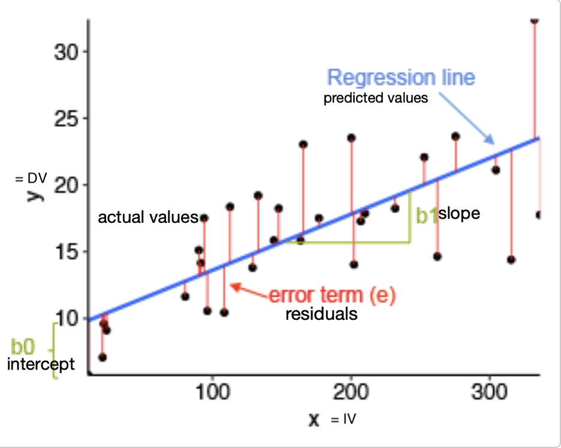

Note: in multiple regression, the formula is the same, it just includes as many predictors as necessary and the regression lines in the graph will reflect that.

### Assumptions

In statistical analyses, all parametric tests assume the data have certain characteristics, also known as *assumptions*. Violating these assumptions changes the conclusion of the research and interpretation of the results.

#### **1. Normality of distribution of data and residuals**

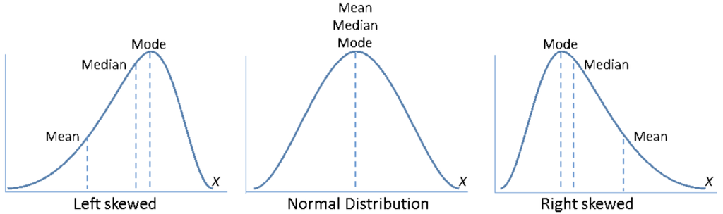

**Note:** * Mean: average * Mode: most common * Median: middle

#### **2. Homogeneity of variance of residuals**

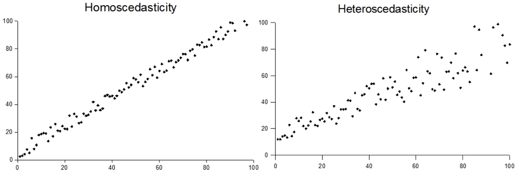

#### **3. Independence of residuals**

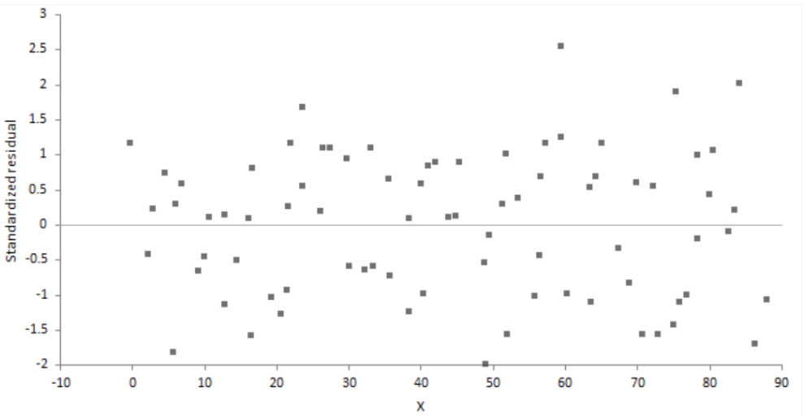

#### **4. Linearity**

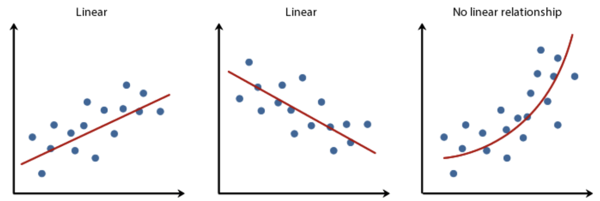

## Regression in practice

Let’s look at some real data from [López-Beltrán et al., (2021)](https://www.researchgate.net/publication/349378127_The_effects_of_information_structure_in_the_processing_of_word_order_variation_in_the_second_language)

We have a 2x2 repeated measures experiment where we want to test if there are differences in the processing of **active and passive sentences depending on information structure**. There is strong evidence that passive sentences are more costly to process than their active counterparts (i.e., higher Reading Times, RTs). However, we hypothesize that the cost of processing passive sentences might be alleviated when they are presented with a *Given-New information structure pattern* that is congruent with their discourse context, as shown below:

[figure not shown]

The following predictions are made:

1. Actives will be read faster than passives
2. Given-New (Congruent) will be read faster than New-Given (Incongruent)
3. Passive New-Given will be the most costly condition (slowest RTs)

In addition,there might be a positive correlation between proficiency (as indexed by vocabulary size) and RTs.  
Let’s visualize it, does the graph seem to meet the predictions?

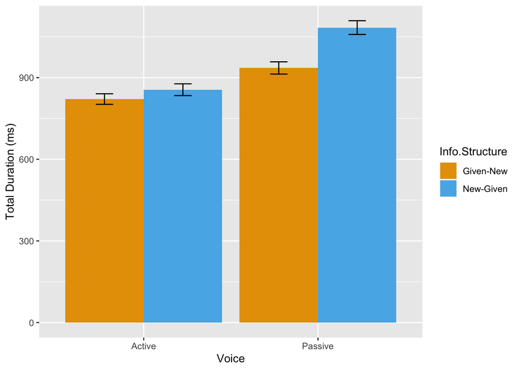

```r
ggplot(data = data, aes(x = voice, y = total, fill = congruency)) +
  stat_summary(fun = mean, position = position_dodge(0.9), geom = "bar") +
  stat_summary(fun.data = mean_se, position = position_dodge(width = 0.9), width = 0.2, geom = "errorbar") +
  xlab("Voice") + ylab("Total Duration (ms)") +
  scale_fill_manual(values=c("#E69F00", "#56B4E9"),
                    name="Info.Structure",
                    breaks=c("Congruent", "Incongruent"),
                    labels=c("Given-New", "New-Given"))
```

## Data preparation

### Centering & Meaningful Intercepts

#### Continuous variables

The intercept of a model is **the mean of the response variable in a hypothetical situation when all predictors = 0**. However, when 0 is out of the range of the predictors analyzed, it becomes meaningless.  
For example, it wouldn’t make much sense to try to interpret the mean of a Reaction Time (RT) response variable when a continuous predictor such as Vocabulary Size, for example, is at 0, as this is not a value we observe in this type of measure.

```r
# BPN_RT stands for Bilingual Picture Naming Reaction Times, a measure of vocabulary size.
summary(data$BPN_RT)
```

```
##    Min. 1st Qu.  Median    Mean 3rd Qu.    Max.
##   612.0   687.0   761.3   775.5   839.1   987.0
```

Fortunately, it’s not hard to adjust things to get a meaningful intercept, we just need to center our continuous predictors.

Centering means to re-scale a predictor so that the mean = 0. This involves subtracting the predictor’s overall mean from each individual value of a predictor (also called *mean centering*). **Thus, centering allows us to establish a meaningful zero point.**

Now, the intercept is easier to interpret because it is centered around 0 and it represents the mean value of the response variable at the mean value of the predictor variable.

```r
BPN_center <- data$BPN_RT - mean(data$BPN_RT)
summary (BPN_center)
```

```
##    Min. 1st Qu.  Median    Mean 3rd Qu.    Max.
## -163.45  -88.51  -14.16    0.00   63.61  211.50
```

#### Categorical variables

As mentioned before, creating dummy variables is necessary if we want to include categorical predictors in a regression model.

The advantage of coded variables is that even though they are technically categorical, we can treat them statistically like continuous variables. However, the method we decide to use will impact the interpretation of the intercept term of our models.

There are several ways of coding variables, here we will learn about the two most common coding schemes:

#### Dummy coding

The simplest form of coding is dummy coding (also called *treatment coding*). This form of coding **compares the mean of each category, to the mean of a baseline**. Thus, the coefficient of each dummy variable will be equal to **the difference between the mean of the dummy variable and the baseline/reference group (i.e., intercept)**. It is very important to consider that dummy variables are *not* independent because they use the same reference level to determine significance, as such, they reflect only *simple effects*, that is, the effect of one variable at one level of another variable.

For example: the intercept is the mean of the response variable RT at the reference level of the predictors Voice and Congruency (i.e., Active-Congruent), and we compare the RTs for the other levels to this baseline.

```r
# Reference = Active
data$dummy_voice <- ifelse(data$voice == "Active", 0, 1)

# Reference = Congruent (i.e., Given-New)
data$dummy_congruency <- ifelse(data$congruency == "Congruent", 0, 1)

# Check coding
xtabs(~ dummy_voice + voice, data)
```

```
##            voice
## dummy_voice Active Passive
##           0    818       0
##           1      0     798
```

#### Sum coding (aka effect coding or contrast coding)

In this form of coding the intercept is equal to **the grand mean of the response variable**. In other words, the average RT value for Voice **and** Congruency.

Thus, the coefficient of the predictor is equal to **the difference between the mean of the predictor and the grand mean of the response variable**. Thus, sum coding reflects *main effects*, that is, the effect of one variable independently of the others.

For example: the intercept is the RT grand mean and and we compare the mean RT of each predictor to this.

```r
# Reference = Active
data$sum_voice <- ifelse(data$voice == "Active", 1, -1)

# Reference = Congruent (i.e., Given-New)
data$sum_congruency <- ifelse(data$congruency == "Congruent", 1, -1)

# Check coding
xtabs(~ sum_voice + voice, data)
```

```
##          voice
## sum_voice Active Passive
##        -1      0     798
##        1     818       0
```

### Centering

Again, we subtract the mean RT from the mean of each predictor. For the sake of simplicity, we’ll center our dummy coded variables as these are more commonly used.

```r
data$center_voice <- data$dummy_voice - mean(data$dummy_voice)
data$center_congruency <- data$dummy_congruency - mean(data$dummy_congruency)

# Voice
summary(data$center_voice)
```

```
##    Min. 1st Qu.  Median    Mean 3rd Qu.    Max.
## -0.4938 -0.4938 -0.4938  0.0000  0.5062  0.5062
```

```r
# Congruency
summary(data$center_congruency)
```

```
##    Min. 1st Qu.  Median    Mean 3rd Qu.    Max.
## -0.4858 -0.4858 -0.4858  0.0000  0.5142  0.5142
```

```r
# save data frame with new centered variables
write.csv(data, "/Users/pul57/Desktop/Work/Workshops/Statistics workshop/data_centered.csv", row.names=FALSE)
```

## Data Analysis

Below, we create the formula for our multiple linear regression model. We use the function `lm()` and first include our response variable (total RTs) followed by *~* and the predictors. If we want these predictors to interact, we place an * between them, as shown below. Finally, we include the data set we are using.

**Notes**

- I am using the function `scale()` to wrap our continuous predictor BPN_RT. Scaling continuous predictors is an alternative to centering them, as it works in a similar fashion.
- We would normally run our model using log-transformed RTs to reduce the right skewness that is common in the distribution of reading data. However, I am not using those for the sake of clarity, as milliseconds are easier to interpret.

```r
model <- lm(total ~ center_voice*center_congruency + scale(BPN_RT), data)
summary(model)
```

```
##
## Call:
## lm(formula = total ~ center_voice * center_congruency + scale(BPN_RT),
##     data = data)
##
## Residuals:
##     Min      1Q  Median      3Q     Max
## -982.93 -293.91  -89.33  200.29 2433.56
##
## Coefficients:
##                                Estimate Std. Error t value Pr(>|t|)
## (Intercept)                      921.80      10.99  83.889  < 2e-16 ***
## center_voice                     170.40      21.98   7.753 1.58e-14 ***
## center_congruency                 89.78      21.99   4.083 4.66e-05 ***
## scale(BPN_RT)                     62.02      10.99   5.642 1.98e-08 ***
## center_voice:center_congruency   114.00      43.97   2.593  0.00961 **
## ---
## Signif. codes:  0 '***' 0.001 '**' 0.01 '*' 0.05 '.' 0.1 ' ' 1
##
## Residual standard error: 441.7 on 1611 degrees of freedom
## Multiple R-squared:  0.06674,    Adjusted R-squared:  0.06443
## F-statistic:  28.8 on 4 and 1611 DF,  p-value: < 2.2e-16
```

Let’s dissect the model’s output:

#### **1. Residuals**

Normally these give us a basic idea about difference between the *observed values* of the response variable and its *predicted values*.  
We can see that the residuals are more or less randomly distributed and form a roughly horizontal band around the residual = 0 line.

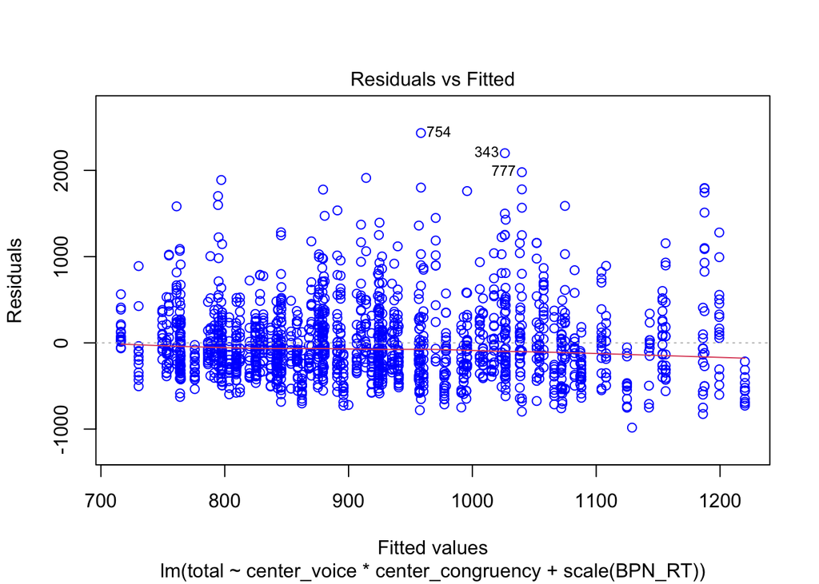

#### **2. Coefficients**

**A. The estimates** represent the mean change in the Total Reading Time response variable for one unit of change (1 ms) in the predictor variable while holding all other predictors in the model constant.*

**B. The standard error (SE)** defines the accuracy of beta coefficients. For a given beta coefficient, the SE reflects how the coefficient varies under repeated sampling. It is used to compute the confidence interval (95%).

**C. p-values** are our test of significance and, together with the t-value, they tell us whether or not the beta coefficient of a predictor is *significantly different from zero*. The higher the t-statistic (2.00 or more) and the lower the p-value, the more significant the predictor

Let’s interpret the estimates. Keep in mind that the coefficients represent the *predicted values*, not the *observed values*, so there might be a slight discrepancy if we compare the values of the estimates and the mean RT for each predictor.

```
## tibble [4 × 2] (S3: tbl_df/tbl/data.frame)
##  $ condition: chr [1:4] "AAC" "API" "PAI" "PPC"
##  $ mean     : num [1:4] 821 1084 856 936
```

```
## [1] "AAC: active given-new, API: passive new-given, PAI: active new-given, PPC: passive given-new"
```

### **3. Model accuracy (aka Goodness-of-fit)**

##### **Residual Standard Error**

The RSE is the residual variation, representing the average variation of the observations points around the fitted regression line. It provides an absolute measure of patterns in the data that can’t be explained by the model.

##### **Multiple R-squared & Adjusted R-squared**

Represent the proportion of variation accounted for by the model. In this case, it only accounts for 6% of variation, indicating that the model’s fit isn’t great.

### **3. Model comparison**

There are other important metrics that are commonly used for model evaluation and selection. These are unbiased estimates of the model’s prediction error. The lower these metrics, the better the model. Here, we will learn about **Akaike’s Information Criterion (AIC)**. The basic idea of AIC is to penalize the inclusion of unnecessary variables in a model. It adds a penalty that increases the error when including additional terms that do not improve the fit.

Using the `glance()` function in the package `broom` we can obtain many measures of accuracy and validation from our model.

```r
model_NI <- lm(total ~ center_voice + center_congruency + scale(BPN_RT), data)
summary(model_NI)
```

```
##
## Call:
## lm(formula = total ~ center_voice + center_congruency + scale(BPN_RT),
##     data = data)
##
## Residuals:
##     Min      1Q  Median      3Q     Max
## -953.28 -292.75  -87.67  198.70 2404.59
##
## Coefficients:
##                   Estimate Std. Error t value Pr(>|t|)
## (Intercept)         921.82      11.01  83.743  < 2e-16 ***
## center_voice        170.40      22.02   7.739 1.75e-14 ***
## center_congruency    89.78      22.03   4.076 4.80e-05 ***
## scale(BPN_RT)        62.01      11.01   5.631 2.11e-08 ***
## ---
## Signif. codes:  0 '***' 0.001 '**' 0.01 '*' 0.05 '.' 0.1 ' ' 1
##
## Residual standard error: 442.5 on 1612 degrees of freedom
## Multiple R-squared:  0.06285,    Adjusted R-squared:  0.06111
## F-statistic: 36.04 on 3 and 1612 DF,  p-value: < 2.2e-16
```

```r
glance(model_NI)
```

```
## # A tibble: 1 × 12
##   r.squared adj.r.squared sigma statistic  p.value    df  logLik    AIC    BIC
##       <dbl>         <dbl> <dbl>     <dbl>    <dbl> <dbl>   <dbl>  <dbl>  <dbl>
## 1    0.0629        0.0611  443.      36.0 1.54e-22     3 -12136. 24283. 24310.
## # ℹ 3 more variables: deviance <dbl>, df.residual <int>, nobs <int>
```

In addition, we can use the `anova()` function to compare model 1 to model 2. The analysis shows that model 1 is significantly better.

```r
anova(model, model_NI)
```

```
## Analysis of Variance Table
##
## Model 1: total ~ center_voice * center_congruency + scale(BPN_RT)
## Model 2: total ~ center_voice + center_congruency + scale(BPN_RT)
##   Res.Df       RSS Df Sum of Sq      F   Pr(>F)
## 1   1611 314340046
## 2   1612 315651478 -1  -1311431 6.7211 0.009614 **
## ---
## Signif. codes:  0 '***' 0.001 '**' 0.01 '*' 0.05 '.' 0.1 ' ' 1
```

### Resources

- General readings
  - Discovering Statistics Using R, by Andy Field
  - How to do Linguistics with R, by Natalia Levshina
  - Altman & Krzywinski (2015) Simple linear regression
  - Gries (2013) Statistics for Linguistics with R: A Practical Introduction
- Anova & Regression
  - https://www.statsimprove.com/en/what-is-the-difference-between-anova-and-regression-and-which-one-to-choose/
  - https://www.statology.org/anova-vs-regression/
  - http://www.sthda.com/english/articles/40-regression-analysis/167-simple-linear-regression-in-r
  - https://blog.minitab.com/blog/adventures-in-statistics-2/regression-analysis-how-do-i-interpret-r-squared-and-assess-the-goodness-of-fit
  - https://feliperego.github.io/blog/2015/10/23/Interpreting-Model-Output-In-R
  - https://www.theanalysisfactor.com/interpreting-regression-coefficients/
- Assumptions
  - http://www.sthda.com/english/articles/39-regression-model-diagnostics/161-linear-regression-assumptions-and-diagnostics-in-r-essentials/
  - https://www.jmp.com/en_us/statistics-knowledge-portal/what-is-regression/simple-linear-regression-assumptions.html
- Factor coding
  - https://www.statisticssolutions.com/dummy-coding-the-how-and-why/
  - https://conjointly.com/kb/dummy-variables/
  - https://it.unt.edu/sites/default/files/categoricalregression_jds_june2010.pdf
  - https://talklab.psy.gla.ac.uk/tvw/catpred/
- Centering & Intercepts
  - https://philippmasur.de/2018/05/23/how-to-center-in-multilevel-models/
  - https://www.theanalysisfactor.com/center-on-the-mean/
  - https://www.theanalysisfactor.com/interpreting-the-intercept-in-a-regression-model/
- Scaling
  - http://stattips.blogspot.com/2009/08/rescaling-continuous-predictors-in.html
  - https://benwhalley.github.io/just-enough-r/scaling-predictors.html
- p-value
  - https://blog.minitab.com/blog/adventures-in-statistics-2/how-to-correctly-interpret-p-values
  - https://www.investopedia.com/terms/p/p-value.asp#:~:text=In%20statistics%2C%20the%20p%2Dvalue,the%20null%20hypothesis%20is%20correct.&text=A%20smaller%20p%2Dvalue%20means,favor%20of%20the%20alternative%20hypothesis.
- Residuals
  - https://blog.minitab.com/blog/adventures-in-statistics-2/why-you-need-to-check-your-residual-plots-for-regression-analysis
- General Statistics in R:
  - chrome-extension://efaidnbmnnnibpcajpcglclefindmkaj/http://www.sfs.uni-tuebingen.de/~hbaayen/publications/baayenCUPstats.pdf